# Weather data

## 6.3 Plot ITP vs. OFD

It would be interesting to see the correlation between imputed OFD and ITP data at the monthly level:

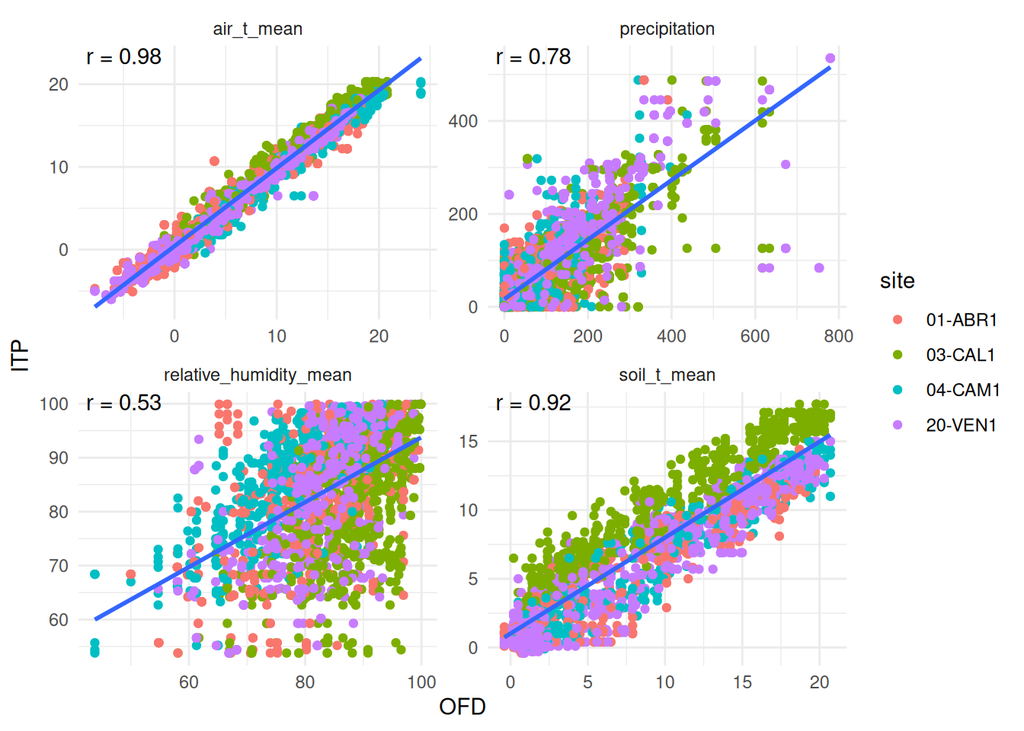

```r
vars <- str_remove(to_plot, "_ITP")

cors <- map_dbl(vars, \(x) imp_overall |>
                 miceadds::micombine.cor(c(paste0(x,"_OFD"), paste0(x,"_ITP"))) |>
                 pluck("r",1)
)

cors <- tibble(variable = vars, cor = cors) |>
  mutate(cor = paste("r =", round(cors, digits = 2)))

pairs <- complete(imp_overall, action = "long") |>
  select(!c(overall, cover, solar_radiation_mean_OFD)) |>
  pivot_longer(ends_with("ITP") | ends_with("OFD"), names_to = c("variable", "type"),
               names_pattern = "(.*)_(.*)", values_to = "value") |>
  pivot_wider(names_from = "type", values_from = "value")

pairs |>
  ggplot(aes(x = OFD, y = ITP)) +
  geom_point(aes(color = site)) +
  geom_smooth(method = "lm", se = F)+
  facet_wrap(~variable, scales = "free")+
  geom_text(data = cors,
            aes(x = -Inf, y = Inf, label = cor),
            hjust = -0.1,
            vjust = 1.1,
            inherit.aes = FALSE)
```

# 7 Correlations, MA regressions, and SD ratios

To evaluate the extent to which air temperature and precipitation measured by sub-canopy stations are different from open-field measurements (for example, lower because of buffering and stemflow), I use correlations, major axis regressions and SD ratios, pooling the results across the imputations.

```r
cor_pool <- function(dat, var1, var2){
  imp_overall |>
    miceadds::micombine.cor(c(var1, var2)) |>
    slice(1) |>
    select(est = r, lo = lower95, hi = upper95)
  }

sdratio_pool <- function(dat, var1, var2){
  pooled <- dat |>
    complete(action = "long") |>
    summarise(q_lsd = log(sd(.data[[var1]]) / sd(.data[[var2]])),
              u_lsd = (1 - cor(.data[[var1]], .data[[var2]])^2) / (n() - 1),
              .by = .imp) |>
    with(pool.scalar(q_lsd, u_lsd))

  est <- pooled$qbar
  int <- 2*sqrt(pooled$t)

  tibble(est = est, lo = est - int, hi = est + int) |>
    exp()
}

MA_pool <- function(dat, var1, var2){
  form <- as.formula(str_c(var1, "~", var2))
  pooled <- dat |>
    complete(action = "all") |>
    map(\(x) suppressMessages(lmodel2(form, x)) |>
          broom::tidy() |>
          filter(method == "MA" & term == "Slope") |>
          mutate(var = (mean(c(conf.high - estimate,
                             estimate - conf.low))/2)^2)) |>
  bind_rows() |>
    with(pool.scalar(estimate, var))

  est <- pooled$qbar
  int <- 2*sqrt(pooled$t)

  tibble(est = est, lo = est - int, hi = est + int)
}
```

The following table reports correlations, SD ratios and MA slopes with approximate 95% CIs:

```r
itp_ofd <- tibble(var = c("air_t_mean", "precipitation"),
       vars = map(var, \(x) c(str_c(x, "_ITP"), str_c(x, "_OFD")))) |>
  mutate(r = map(vars, \(x) cor_pool(imp_overall, x[1], x[2])),
         `SD ratio` = map(vars, \(x) sdratio_pool(imp_overall, x[1], x[2])),
         `MA slope` = map(vars, \(x) MA_pool(imp_overall, x[1], x[2])),
         var = recode_values(var,
                             "air_t_mean" ~ "Mean air temperature",
                             "precipitation" ~ "Precipitation")) |>
  select(!vars) |>
  pivot_longer(r:`MA slope`) |>
  unnest_wider(value) |>
  mutate(across(est:hi, \(x) round(x, 2)),
         out = str_c(est, " (", lo, "–", hi, ")")) |>
  select(var, name, out) |>
  pivot_wider(names_from = name, values_from = out)

itp_ofd
```

| var | r | SD ratio | MA slope |
| --- | --- | --- | --- |
| Mean air temperature | 0.98 (0.98–0.99) | 0.96 (0.94–0.97) | 0.96 (0.94–0.97) |
| Precipitation | 0.78 (0.74–0.81) | 0.82 (0.76–0.9) | 0.78 (0.7–0.86) |

```r
write_csv(itp_ofd, "output/itp_ofd_comparison.csv")
```

# 8 Save results

```r
#convert mids to list of dataframes, clean columns, calculate annual means
finish_weat <- function(x, fd){
  x |>
    #keep only data for FD survey years
    semi_join(dates |>
                select(site, survey_year) |>
                mutate(across(everything(), as_factor))) |>
    #keep only weather variables
    select(!any_of(c("month", "year", "cover", "above", "below", "overall"))) |>
    #calculate 12-month means for each survey
    group_by(site, survey_year) |>
    summarise(across(everything(), mean), .groups = "drop") |>
    #precipitation multiplied by 12 because it's an extensive property
    mutate(across(contains("precipitation"), \(x) x * 12)) |>
    rename(year = survey_year) |>
    #join FD outcome
    inner_join(results_sites |>
                 select(all_of(c("year", "site", "subplot", fd))) |>
                 mutate(across(c(site, year), as_factor)),
                        relationship = "one-to-many") |>
    #rearrange columns and pivot back to long
    relocate(any_of(c("subplot", "above", "below", "overall")), .after = year) |>
    pivot_longer(5:last_col(),
                 names_to = c(".value", "type"),
                 names_sep = "_(?=[^_]+$)") |>
    #OFD not needed here
    filter_out(type == "OFD") |>
    # CAM has no observed ITP data, those should probably not be used in models
    filter_out(site == "04-CAM1") |>
    #remove unnecessary columns
    select(!c(type, solar_radiation_mean))
}

data_ITP_above <- complete(imp_above, action = "all") |>
  lapply(finish_weat, "above")

data_ITP_below <- complete(imp_below, action = "all") |>
  lapply(finish_weat, "below")

data_ITP_overall <- complete(imp_overall, action = "all") |>
  lapply(finish_weat, "overall")

#join FD outcome for OFD
data_OFD <- complete_OFD |>
  map(\(x) x|>
        mutate(across(c(site, survey_year), as_factor)) |>
        inner_join(results_sites |>
                     mutate(across(c(site, year), as_factor)),
                   by = c("survey_year" = "year", "site" = "site"),
                   relationship = "one-to-many") |>
        mutate(survey_year = fct_drop(survey_year)) |>
        rename(year = survey_year)
  )


#save
save(data_OFD, data_ITP_above, data_ITP_below, data_ITP_overall, file = "intermediate/weather.RData")
saveRDS(weat_imp_raw, "intermediate/weat.rds")
saveRDS(dates, "intermediate/dates.rds")
```

## References

Audigier, Vincent, Ian R. White, Shahab Jolani, et al. 2018. “Multiple Imputation for Multilevel Data with Continuous and Binary Variables.” *Statistical Science* 33 (2): 160–83. https://doi.org/10.1214/18-STS646.

D’Agostino McGowan, Lucy, Sarah C Lotspeich, and Staci A Hepler. 2024. “The “Why” Behind Including “y” in Your Imputation Model.” *Statistical Methods in Medical Research* 33 (6): 996–1020. https://doi.org/10.1177/09622802241244608.

Sterne, Jonathan A. C., Ian R. White, John B. Carlin, et al. 2009. “Multiple Imputation for Missing Data in Epidemiological and Clinical Research: Potential and Pitfalls.” *BMJ* 338 (June): b2393. https://doi.org/10.1136/bmj.b2393.

White, Ian R., Patrick Royston, and Angela M. Wood. 2011. “Multiple Imputation Using Chained Equations: Issues and Guidance for Practice.” *Statistics in Medicine* 30 (4): 377–99. https://doi.org/10.1002/sim.4067.